# *Nephila edulis* data analysis

Philip Bateman (Curtin University) & Blake C Jones (University of Memphis)

September 8, 2016

### **Background:**

*Nephila edulis* is an orb-weaver commonly found in Australia. These spiders often incorporate decaying vegetation and previously captured prey to form vertical debris trails in their webs. Previous work suggests these trails function to attract potential prey (Bjorkman-Chriswell et al. 2004). However, **we hypothesize that debris trails serve to increase a spiders crypsis during close encounters with potential predators**. Indeed, *N. edulis* will often align its body with the debris trail when a human approaches its web. We make two predictions from our hypothesis.

- **P1.** Individuals with longer debris trails will have shorter flight initiation distances (FID) when approached by a human.
- **P2.** Individuals with longer debris trails are more likely to align with the debris trail rather than flee when a human approaches their web.

### **Data analysis:**

#### **Setup:**

install the necessary packages and load them

```r
install.packages("ggplot2")
install.packages("car")
library(ggplot2)
```

Set working directory and upload data.

```r
setwd("~/working_directory")
DATA <- read.csv("./file_location.csv")
```

#### **Data:**

Check the sturcture of the data

```r
str(DATA)
head(DATA)
```

create a new factor variable for the dummy coded behaviour variable

```r
DATA$fbehaviour_dummy_coded <- factor(DATA$behaviour_dummy_coded)
```

#### **Testing P1: graphs**

Let’s take a look at the data graphically.

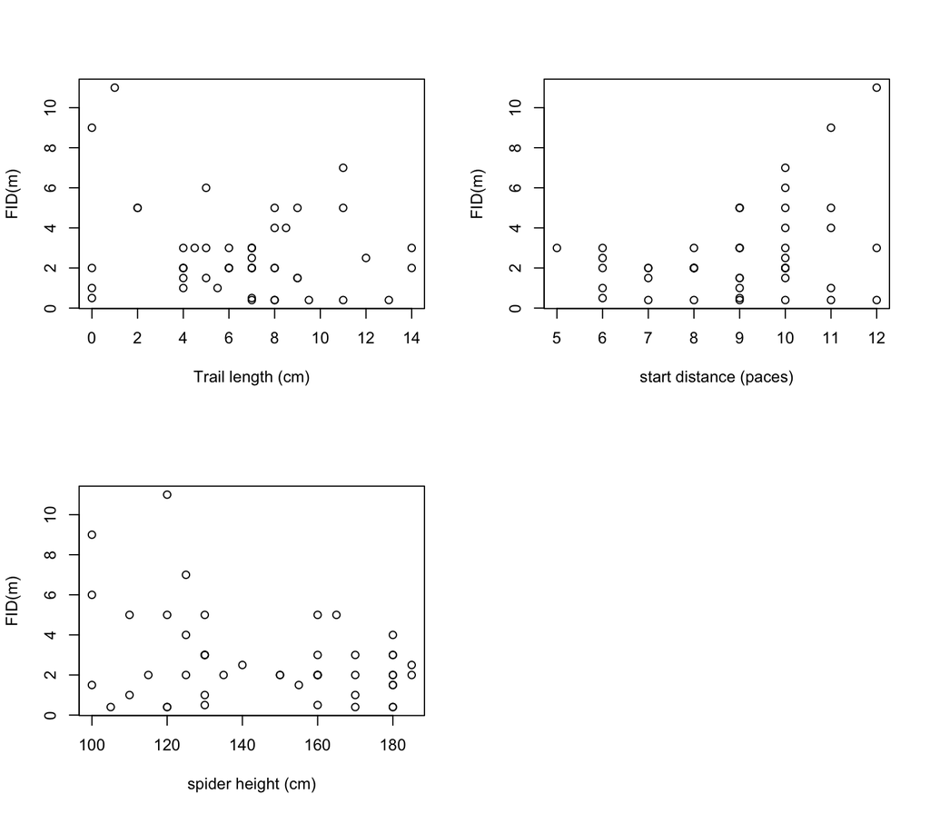

```r
par(mfrow=c(2,2))
plot(DATA$debris_trail_length, DATA$FID, ylab= "FID(m)", xlab = "Trail length (cm)")
plot(DATA$start_distance, DATA$FID, ylab= "FID(m)", xlab = "start distance (paces)")
plot(DATA$spider_height, DATA$FID, ylab= "FID(m)", xlab = "spider height (cm)")
```

#### **Testing P1: model**

Run a simple linear regression model with FID as the response variable, debris trail length as the predictor variable, and the spider’s height off the ground and the approacher’s start distance as covariates.

```r
regression <- lm(FID ~ debris_trail_length +
                   spider_height + start_distance, data = DATA)
summary(regression)
```

```
##
## Call:
## lm(formula = FID ~ debris_trail_length + spider_height + start_distance,
##     data = DATA)
##
## Residuals:
##     Min      1Q  Median      3Q     Max
## -3.5390 -1.0479  0.0533  0.9577  5.9747
##
## Coefficients:
##                     Estimate Std. Error t value Pr(>|t|)
## (Intercept)          2.69883    2.32628   1.160   0.2521
## debris_trail_length -0.09486    0.08458  -1.121   0.2680
## spider_height       -0.02009    0.01097  -1.831   0.0737 .
## start_distance       0.40273    0.16778   2.400   0.0206 *
## ---
## Signif. codes:  0 '***' 0.001 '**' 0.01 '*' 0.05 '.' 0.1 ' ' 1
##
## Residual standard error: 1.997 on 45 degrees of freedom
## Multiple R-squared:  0.2227, Adjusted R-squared:  0.1709
## F-statistic: 4.297 on 3 and 45 DF,  p-value: 0.009491
```

trail length does not seem to affect FID, but start distance is statistically significant.

Now, let’s take a look at the confidence intervals.

```r
confint(regression, level = 0.95)
```

```
##                           2.5 %      97.5 %
## (Intercept)         -1.98653489 7.384197136
## debris_trail_length -0.26521371 0.075502701
## spider_height       -0.04219295 0.002003667
## start_distance       0.06480775 0.740645308
```

#### **Testing P1: assumptions**

Let’s see if our model meets the assumptions of a general linear model.

Check for heteroscedasticity

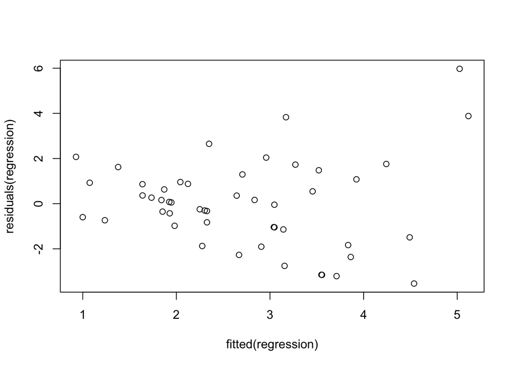

```r
plot(fitted(regression),residuals(regression))
```

There is significant heteroscedasticity.

Check for multicollinearity

```r
library(car)
vif(regression)
```

```
## debris_trail_length       spider_height      start_distance
##            1.046616            1.060734            1.014476
```

```r
detach("package:car")
```

vif values > 4 or 5 are considered to be colinear. Our values are all just over 1, so multicollinearity is not a problem.

Check for linearity

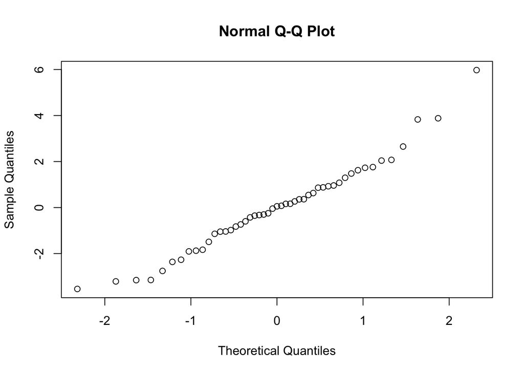

```r
qqnorm(residuals(regression))
```

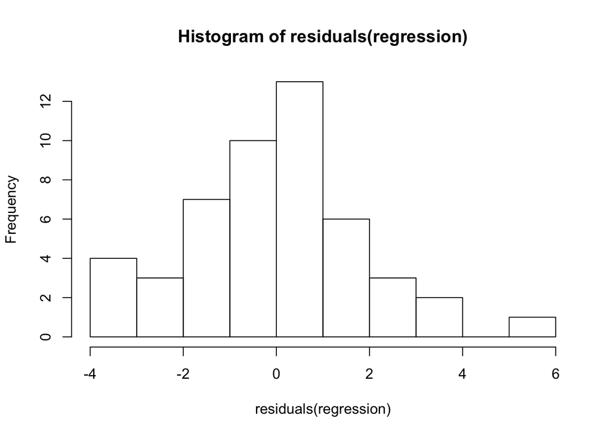

```r
hist(residuals(regression))
```

The data set looks normally distributed

#### **Testing P1: correcting for heteroscedasticity**

The redisuals show significant heteroscedasticity, which could lead to a false rejection of the null hypothesis, so we log transform the response variable to see if that creates more homogenous variance.

Create a new variable of the log transformed FID, and append it to the data set.

```r
FIDlog <- log(DATA$FID)
DATA <- cbind(DATA, FIDlog)
```

Rerun the regression model with the transformed response variable.

```r
regression <- lm(FIDlog ~ debris_trail_length +
                   spider_height + start_distance, data = DATA)
```

Rerun the model assumptions.

Check for heteroscedasticity

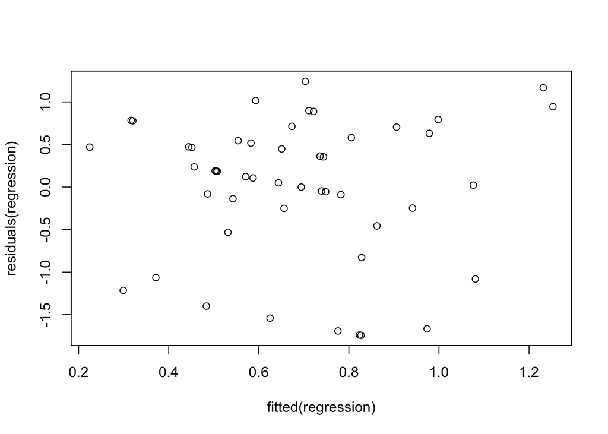

```r
plot(fitted(regression),residuals(regression))
```

The residuals are now homoscedastic.

Check for multicollinearity

```r
library(car)
vif(regression)
```

```
## debris_trail_length       spider_height      start_distance
##            1.046616            1.060734            1.014476
```

```r
detach("package:car")
```

vif values > 4 or 5 are considered to be colinear. Our values are all just over 1, so multicollinearity is not a problem.

Check for linearity

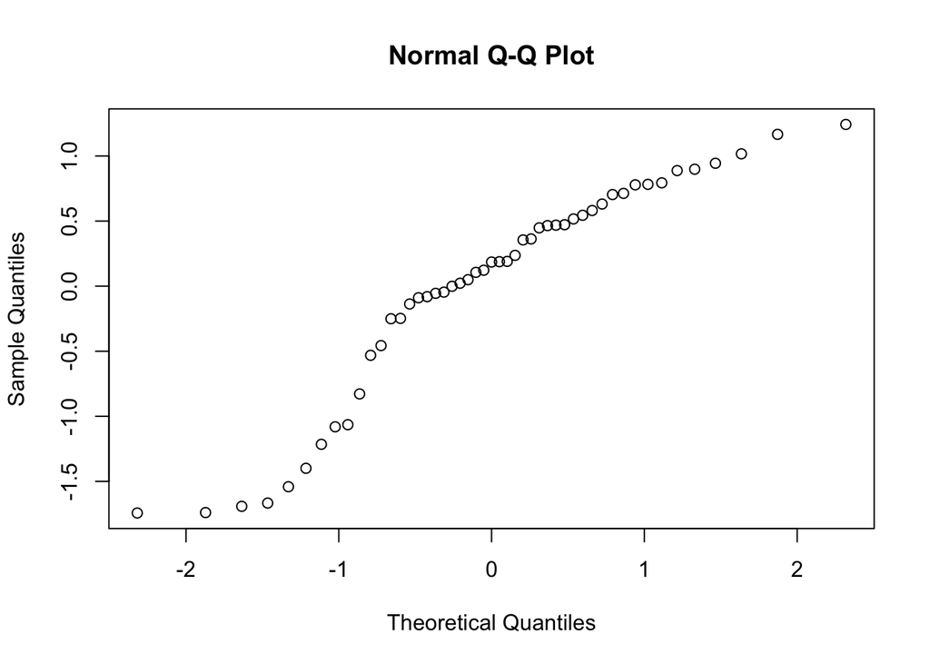

```r
qqnorm(residuals(regression))
```

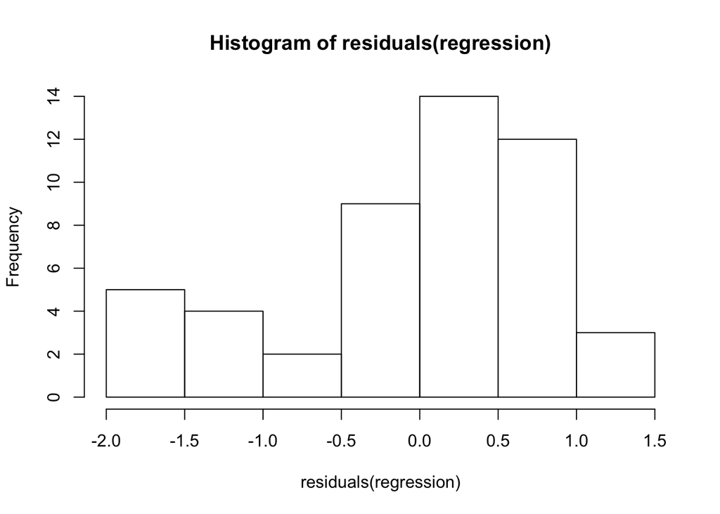

```r
hist(residuals(regression))
```

The transformed dataset is no longer linear. At this point, it is better to wait and see how the expanded dataset will alter the distribution before deciding how to move forward.

#### **Testing P2: graphs**

Let’s take a look at the data graphically.

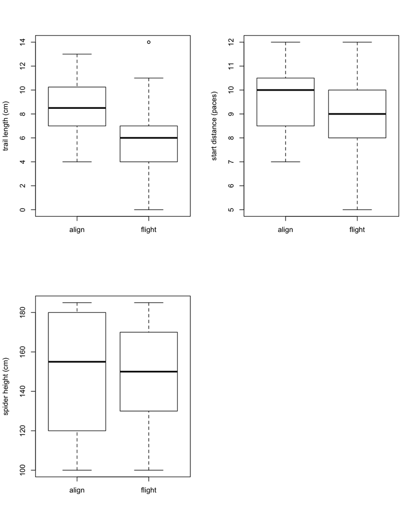

```r
par(mfrow=c(2,2))
plot(DATA$behaviour, DATA$debris_trail_length, ylab= "trail length (cm)")
plot(DATA$behaviour, DATA$start_distance, ylab = "start distance (paces)")
plot(DATA$behaviour, DATA$spider_height, ylab = "spider height (cm)")
```

#### **Testing P2: model**

Run a generlized linear model (logit regression) with first order interaction to test for homogenity of regression slopes (an assumption of regression models).

```r
int_1 <- glm(fbehaviour_dummy_coded ~ debris_trail_length*start_distance +
                   debris_trail_length*spider_height, data = DATA,
                 family = binomial)

summary(int_1)
```

```
##
## Call:
## glm(formula = fbehaviour_dummy_coded ~ debris_trail_length *
##     start_distance + debris_trail_length * spider_height, family = binomial,
##     data = DATA)
##
## Deviance Residuals:
##     Min       1Q   Median       3Q      Max
## -1.6832  -0.7589  -0.4692   0.8896   2.0782
##
## Coefficients:
##                                     Estimate Std. Error z value Pr(>|z|)
## (Intercept)                        -3.673622   8.376441  -0.439    0.661
## debris_trail_length                 0.037969   0.944525   0.040    0.968
## start_distance                      0.055383   0.577617   0.096    0.924
## spider_height                       0.002312   0.036703   0.063    0.950
## debris_trail_length:start_distance  0.048189   0.071226   0.677    0.499
## debris_trail_length:spider_height  -0.001272   0.004410  -0.288    0.773
##
## (Dispersion parameter for binomial family taken to be 1)
##
##     Null deviance: 60.364  on 48  degrees of freedom
## Residual deviance: 49.036  on 43  degrees of freedom
## AIC: 61.036
##
## Number of Fisher Scoring iterations: 4
```

We remover the least significant interactions and examine trail length by start distance interaction alone.

```r
int_2 <- glm(fbehaviour_dummy_coded ~ debris_trail_length*start_distance +
               spider_height, data = DATA,
             family = binomial)

summary(int_2)
```

```
##
## Call:
## glm(formula = fbehaviour_dummy_coded ~ debris_trail_length *
##     start_distance + spider_height, family = binomial, data = DATA)
##
## Deviance Residuals:
##     Min       1Q   Median       3Q      Max
## -1.6389  -0.7600  -0.4847   0.8159   2.0835
##
## Coefficients:
##                                     Estimate Std. Error z value Pr(>|z|)
## (Intercept)                        -1.978147   5.913430  -0.335    0.738
## debris_trail_length                -0.163360   0.636816  -0.257    0.798
## start_distance                      0.021306   0.558244   0.038    0.970
## spider_height                      -0.007532   0.013568  -0.555    0.579
## debris_trail_length:start_distance  0.050400   0.070279   0.717    0.473
##
## (Dispersion parameter for binomial family taken to be 1)
##
##     Null deviance: 60.364  on 48  degrees of freedom
## Residual deviance: 49.119  on 44  degrees of freedom
## AIC: 59.119
##
## Number of Fisher Scoring iterations: 4
```

There is no evidence that there is a significant interaction among our main terms, therefore we can assume homogenity of regression slopes and analyze the main effects.

```r
logit_GLM <- glm(fbehaviour_dummy_coded ~ debris_trail_length + start_distance +
                            spider_height, data = DATA,
                          family = binomial)
summary(logit_GLM)
```

```
##
## Call:
## glm(formula = fbehaviour_dummy_coded ~ debris_trail_length +
##     start_distance + spider_height, family = binomial, data = DATA)
##
## Deviance Residuals:
##     Min       1Q   Median       3Q      Max
## -1.6121  -0.7766  -0.4648   0.8714   2.1868
##
## Coefficients:
##                      Estimate Std. Error z value Pr(>|z|)
## (Intercept)         -5.784809   2.973647  -1.945   0.0517 .
## debris_trail_length  0.289344   0.115206   2.512   0.0120 *
## start_distance       0.393151   0.224409   1.752   0.0798 .
## spider_height       -0.004574   0.012847  -0.356   0.7218
## ---
## Signif. codes:  0 '***' 0.001 '**' 0.01 '*' 0.05 '.' 0.1 ' ' 1
##
## (Dispersion parameter for binomial family taken to be 1)
##
##     Null deviance: 60.364  on 48  degrees of freedom
## Residual deviance: 49.671  on 45  degrees of freedom
## AIC: 57.671
##
## Number of Fisher Scoring iterations: 4
```

Debris trail length is statistically significant and start distance is nearly so. The estimates are the direction and magnitude of the log-odds for each factor.

Let’s get the overall statistical significance of the model via likelihood ratio test. First, create the null model to compare to the full model. Second, perform a chi square comparison

```r
null <- glm(fbehaviour_dummy_coded ~ 1, data = DATA,
            family = binomial)
anova(null, logit_GLM, test = "Chisq")
```

```
## Analysis of Deviance Table
##
## Model 1: fbehaviour_dummy_coded ~ 1
## Model 2: fbehaviour_dummy_coded ~ debris_trail_length + start_distance +
##     spider_height
##   Resid. Df Resid. Dev Df Deviance Pr(>Chi)
## 1        48     60.364
## 2        45     49.671  3   10.694   0.0135 *
## ---
## Signif. codes:  0 '***' 0.001 '**' 0.01 '*' 0.05 '.' 0.1 ' ' 1
```

Logit regression graph

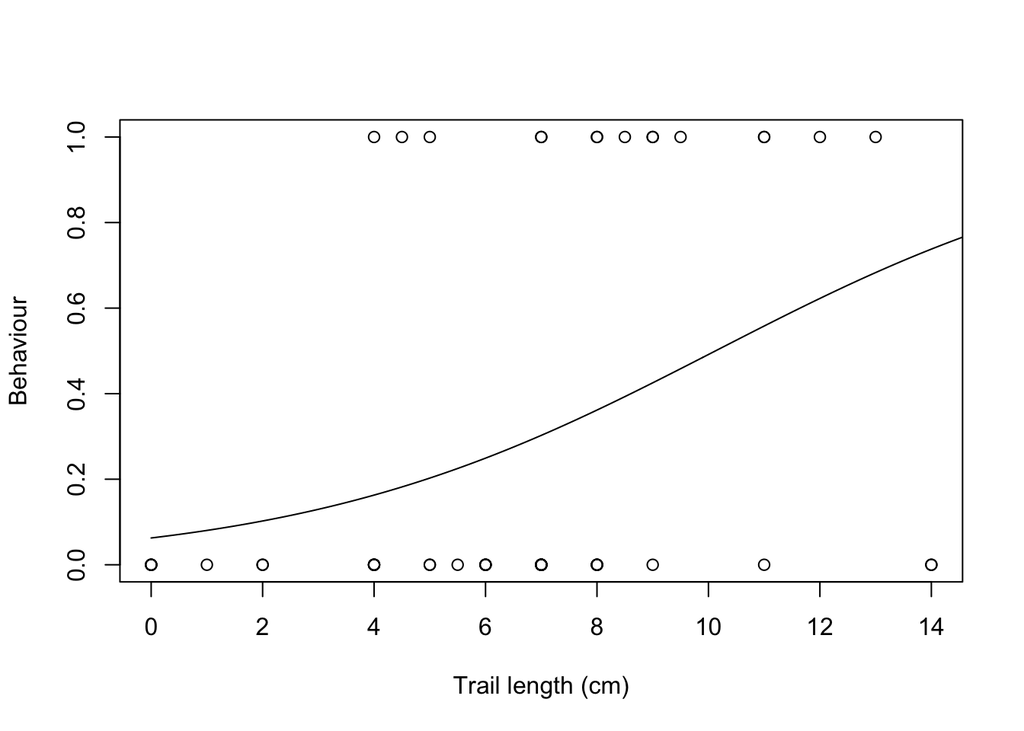

```r
GLM <- glm(fbehaviour_dummy_coded ~ debris_trail_length, data = DATA,
                 family = binomial)

MyData <- data.frame(debris_trail_length = seq(from = 0, to = 15, by = 0.1))
Pred <- predict(GLM, newdata = MyData, type = "response")
plot(y = DATA$behaviour_dummy_coded, x = DATA$debris_trail_length, xlab = "Trail length (cm)", ylab = "Behaviour")
lines(MyData$debris_trail_length, Pred)
```

obtain the 95% confidence intervals of the log-odds (i.e., coeffeicent estimates)

```r
confint(logit_GLM, level = 0.95)
```

```
##                            2.5 %      97.5 %
## (Intercept)         -12.16513705 -0.28310000
## debris_trail_length   0.08015222  0.54076808
## start_distance       -0.02066258  0.87576992
## spider_height        -0.03050175  0.02068917
```

Obtain the odds ratios and thier respective 95% confidence intervals

```r
exp(cbind(Odds_ratios = coef(logit_GLM), confint(logit_GLM)))
```

```
##                     Odds_ratios        2.5 %    97.5 %
## (Intercept)         0.003073897 5.208925e-06 0.7534444
## debris_trail_length 1.335551517 1.083452e+00 1.7173254
## start_distance      1.481642684 9.795494e-01 2.4007230
## spider_height       0.995436453 9.699587e-01 1.0209047
```

#### **Testing P2: conclusions**

Debris trail length had a statistically significant effect on whether a spider fled (*p* = 0.012). For every cm increase in debris trail length spiders were more likely to align by a factor of 1.34.

The overall statistical significance of the logit regression was *p* = 0.014.

**References:** Bjorkman-Chiswell, B. T., Kulinski, M. M., Muscat, R. L., Nguyen, K. A., Norton, B. A., Symonds, M. R., … & Elgar, M. A. (2004). Web-building spiders attract prey by storing decaying matter. Naturwissenschaften, 91(5), 245-248.